# Stat 579 - Homework #8 - Section A

10/24/2019

## Urban stream monitoring

For this homework, we will be using the Ames City Urban stream monitoring project available at https://www.cityofames.org/government/departments-divisions-i-z/water-pollution-control/urban-stream-monitoring

1. Download the RMarkdown file with these homework instructions to use as a template for your work. Make sure to replace “Your Name” in the YAML with your name.
2. Read the information available on the Urban Stream Monitoring project https://www.cityofames.org/government/departments-divisions-i-z/water-pollution-control/urban-stream-monitoring

The table presented on this website can be read into R using the following couple of commands.

```r
library(tidyverse)
library(rvest)
url <- "https://www.cityofames.org/government/departments-divisions-i-z/water-pollution-control/urban-stream-monitoring"
doc <- read_html(url)
tables <- doc %>% html_table(fill=TRUE)
ames <- data.frame(tables[[1]])
head(ames)
```

```
##          Sample.Date Skunk.River Squaw.Creek Clear.Creek College.Creek
## 1   October 11, 2019         558         758         268         1,024
## 2 September 24, 2019       1,764       1,446         320           904
## 3     August 6, 2019         122       2,909       6,867         8,664
## 4      July 16, 2019         839       5,172      24,196       >24,196
## 5      June 11, 2019         173         374         414           583
## 6       May 16, 2019          63         231         189           265
##   Worle.Creek
## 1         378
## 2       1,024
## 3       3,448
## 4       2,098
## 5         594
## 6         384
```

The overarching goal of this homework is to clean the data and get it into a format ready for an analysis.

3. Bring the data into long form.

```r
# delete the empty row
ames <- ames[-nrow(ames),]
ames.ll <- ames %>% pivot_longer(Skunk.River:Worle.Creek, names_to = "River_name",
                                 values_to = "Measurement")

head(ames.ll)
```

```
## # A tibble: 6 x 3
##   Sample.Date        River_name    Measurement
##   <chr>              <chr>         <chr>
## 1 October 11, 2019   Skunk.River   558
## 2 October 11, 2019   Squaw.Creek   758
## 3 October 11, 2019   Clear.Creek   268
## 4 October 11, 2019   College.Creek 1,024
## 5 October 11, 2019   Worle.Creek   378
## 6 September 24, 2019 Skunk.River   1,764
```

4. Measurements of E.Coli are in character format. Convert these values properly into numbers. How many missing values are there? What is the average of the measurements?

```r
ames.ll <- ames.ll %>% mutate(
  measurement.p = parse_number(Measurement, na=c("", "---", "-"))
)

# number of missing values
ames.ll %>% summarise(
  missing = sum(is.na(measurement.p)),
  average = mean(measurement.p, na.rm = T)
)
```

```
## # A tibble: 1 x 2
##   missing average
##     <int>   <dbl>
## 1      33   2809.
```

- Since I deleted one empty row, there are 33 missing values. And the average of the measurements is 2809.
5. The `Sample.Date` variable is a mess. Use `separate` to get the information into Month, Day and Year. Make sure that the `Sample.Date` variable is not being removed from the data in this process.

```r
ames.ll <- ames.ll %>% separate(Sample.Date, c("Month", "Day", "Year"),
                                remove = F, fill="left")

# reorder the month
ames.ll <- ames.ll %>% mutate(
  Month = as.factor(Month),
  Month = factor(Month, levels(Month)[rev(c(1, 5, 4, 3, 2, 7, 6))])
)

ames.ll %>% select(Sample.Date, Month, Day, Year) %>% head()
```

```
## # A tibble: 6 x 4
##   Sample.Date        Month     Day   Year
##   <chr>              <fct>     <chr> <chr>
## 1 October 11, 2019   October   11    2019
## 2 October 11, 2019   October   11    2019
## 3 October 11, 2019   October   11    2019
## 4 October 11, 2019   October   11    2019
## 5 October 11, 2019   October   11    2019
## 6 September 24, 2019 September 24    2019
```

6. Plot measurements by month, colour by creek, and facet by year. Describe the plot in 2-3 sentences.

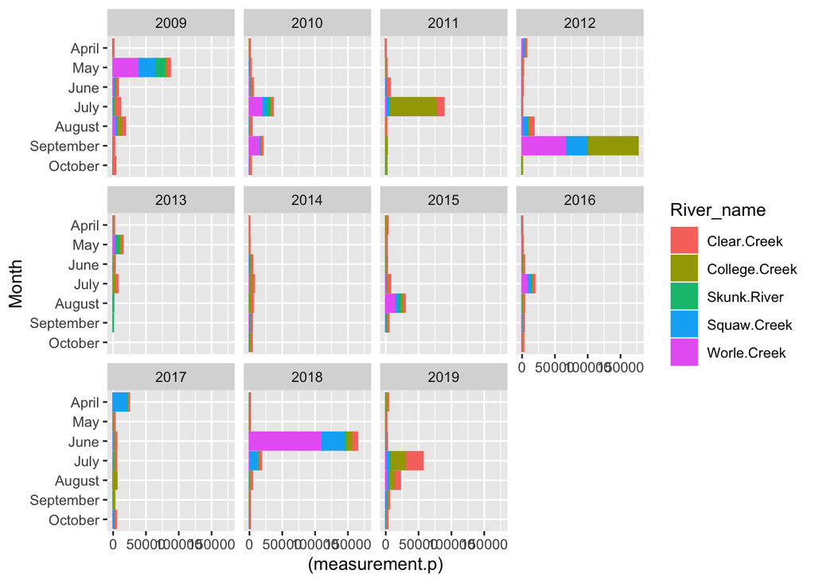

```r
ames.ll %>% filter(!is.na(Month)) %>%
  ggplot(aes(x=Month, y=(measurement.p), colour=River_name)) +
  geom_bar(aes(fill=River_name), stat="identity") +
  facet_wrap(~Year) +
  coord_flip()
```

- These bar plots show the measurements for each creek in different months and different years. This is not a perfect visualization since it’s hard to compare the measurements among those creeks, but this visualization can show that which month gives the highest measurement for all five creeks given a year. Also, it shows that which creek contributes the most to the highest measurement. For example, September 2012 had very high measurement, to which the Worle Creek, Squaw Creek and College Creek contribute the most.
7. Introduce a variable `Type` into the dataset that is `fecal coliform bacteria` for measurements before August 14, 2018 and `E.coli` for measurements taken afterwards.

```r
ames.ll <- ames.ll %>% mutate(
  Type = ifelse(Year == "2019" |
                  (Year == "2018" &
                     (Month == "August" | Month == "September" | Month == "October")),
          "E.coli", "fecal coliform bacteria")
)
ames.ll %>% head()
```

```
## # A tibble: 6 x 8
##   Sample.Date  Month Day   Year  River_name Measurement measurement.p Type
##   <chr>        <fct> <chr> <chr> <chr>      <chr>               <dbl> <chr>
## 1 October 11,… Octo… 11    2019  Skunk.Riv… 558                   558 E.co…
## 2 October 11,… Octo… 11    2019  Squaw.Cre… 758                   758 E.co…
## 3 October 11,… Octo… 11    2019  Clear.Cre… 268                   268 E.co…
## 4 October 11,… Octo… 11    2019  College.C… 1,024                1024 E.co…
## 5 October 11,… Octo… 11    2019  Worle.Cre… 378                   378 E.co…
## 6 September 2… Sept… 24    2019  Skunk.Riv… 1,764                1764 E.co…
```

8. `lubridate` is an R package for working with times and dates. Use [RStudio’s cheatsheet for lubridate](https://github.com/rstudio/cheatsheets/raw/master/lubridate.pdf) to find a way to convert the variable `Sample.Date` to a date.

```r
library(lubridate)
ames.ll <- ames.ll %>% mutate(
  Date = mdy(Sample.Date)
)

ames.ll %>% select(Sample.Date, Date)
```

```
## # A tibble: 380 x 2
##    Sample.Date        Date
##    <chr>              <date>
##  1 October 11, 2019   2019-10-11
##  2 October 11, 2019   2019-10-11
##  3 October 11, 2019   2019-10-11
##  4 October 11, 2019   2019-10-11
##  5 October 11, 2019   2019-10-11
##  6 September 24, 2019 2019-09-24
##  7 September 24, 2019 2019-09-24
##  8 September 24, 2019 2019-09-24
##  9 September 24, 2019 2019-09-24
## 10 September 24, 2019 2019-09-24
## # … with 370 more rows
```